# Statistique Descriptive

Kossi Tonyi Wobubey ABOTSI

default

### Importation des données :

```r
# install.packages("readxl")

# Load the readxl package


# Read data from the Excel file
data <- read_excel("données pour R_28 classes_ MEFG_22 24.xlsx")
#Selection des colonnes utile
data = data  %>% dplyr::select(college:classe,`taille_cm`: gender,sb:pmvpa,time,CA:`CSP_P2`)

#Renommage des colonnes
colnames(data)[23:24] = c("CSP_père","CSP_mère")

#Caste
data$weight_kg = as.double(data$weight_kg)
data$taille_cm = as.double(data$taille_cm)
data$age = as.integer(data$age)
data$time = as.double(data$time)

#Ajout de colonne des IMC
data$IMC_kg_m2 <- data$weight_kg / (data$taille_cm * 10^-2)^2

# Ajout d'une nouvelle colonne "IPS_categorie"
data$IPS_categorie <- ifelse(data$IPS < 89, "Faible",
                             ifelse(data$IPS >= 90 & data$IPS <= 114, "Moyenne", "Élevée"))


#Résolution du problème de facteur double
data$gender = ifelse(data$gender != 'M' & data$gender != 'F', 'M', data$gender)

#Suppression des valeurs manquantes
data = na.omit(data)
#data = data  %>%
#  filter(data$CSP_mère != 'NA' & data$CSP_père != 'NA')

# Print the first few rows of the data to verify
head(data)
```

```
## # A tibble: 6 × 26
##   college classe taille_cm weight_kg   age gender    sb   lpa   mpa   vpa psb
##   <chr>   <chr>      <dbl>     <dbl> <int> <chr>  <dbl> <dbl> <dbl> <dbl> <chr>
## 1 aigle   3.P          157        55    15 F       26.3  4.83  21.2  2.33 47,88…
## 2 aigle   3.P          178        61    14 M       14    8.33  28    4    25,45…
## 3 aigle   3.P          170        75    15 M       20.3  7.33  21.8  5    36,97…
## 4 aigle   3.P          153        68    15 F       26.2  7.33  18.7  2.83 47,58…
## 5 aigle   3.P          181        95    15 M       12.2 12.3   22.3  6.17 22,12…
## 6 aigle   3.P          164        51    15 F       20.5  6.5   20.3  4.83 37,27…
## # ℹ 15 more variables: pla <chr>, pmpa <chr>, pvpa <chr>, mvpa <dbl>,
## #   pmvpa <chr>, time <dbl>, CA <dbl>, activites <chr>, IPS <dbl>,
## #   cat_IPS <chr>, Geographie <chr>, CSP_père <chr>, CSP_mère <chr>,
## #   IMC_kg_m2 <dbl>, IPS_categorie <chr>
```

### **Statistique descriptive de la Population**

Calculons l’age moyens des filles et garçons et l’age moyen des participants.

1. **Age moyen des Participants**

   ```r
   age_sexe_data=data %>%
     group_by(gender) %>%
     summarise(age_total = sum(age),effectif = n())

   age_moyen = sum(age_sexe_data$age_total)/sum(age_sexe_data$effectif)

   age_moyen
   ```

   ```
   ## [1] 13.65499
   ```

   Donc l’age moyen des participants est **13.65**.
2. Moyenne de mvpa des fille et garçon

   ```r
   mean(data$mvpa)
   ```

   ```
   ## [1] 35.13881
   ```

   ```r
   data %>%
     group_by(gender) %>%
     summarise(mean(mvpa))
   ```

   ```
   ## # A tibble: 2 × 2
   ##   gender `mean(mvpa)`
   ##   <chr>         <dbl>
   ## 1 F              31.4
   ## 2 M              38.5
   ```

3. **L’age moyen des filles et garçons**

```r
age_sexe_data$age_moyen = age_sexe_data$age_total/age_sexe_data$effectif


age_sexe_data
```

```
## # A tibble: 2 × 4
##   gender age_total effectif age_moyen
##   <chr>      <int>    <int>     <dbl>
## 1 F           2418      177      13.7
## 2 M           2648      194      13.6
```

| Sexe | F | M | Participant(les deux sexes) |
| --- | --- | --- | --- |
| **Age Moyen** | 13.66 | 13.65 | 13.65 |

- **IMC moyen selon le sexe**

```r
data %>%
  group_by(gender) %>%
  summarise(IMC_moyen = mean(na.omit(IMC_kg_m2)))
```

```
## # A tibble: 2 × 2
##   gender IMC_moyen
##   <chr>      <dbl>
## 1 F           22.4
## 2 M           22.2
```

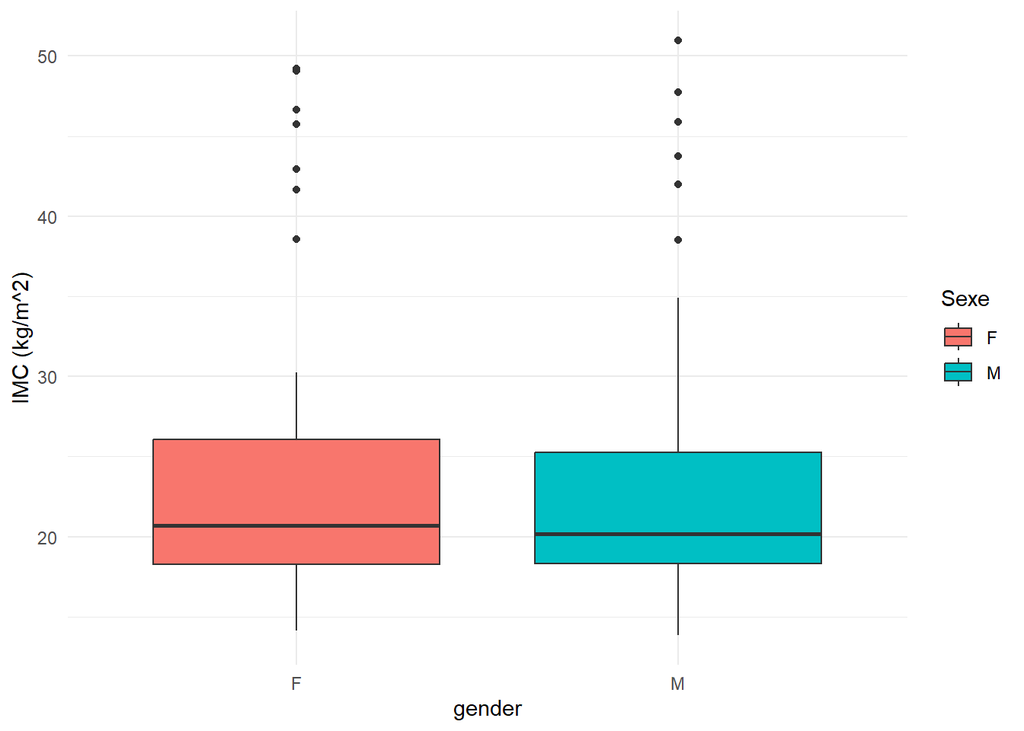

```r
# Créer le diagramme en boîte pour l'IMC par classe et sexe
ggplot(data, aes(x = gender, y = IMC_kg_m2, fill = gender)) +
  geom_boxplot() +
  labs(x = "gender", y = "IMC (kg/m^2)", fill = "Sexe") +
  theme_minimal()
```

En moyenne l’IMC des filles est légèrement plus grand que celui des garçons.

```r
mean(data$IMC_kg_m2)
```

```
## [1] 22.29897
```

En général la moyenne des IMC est de **22.3**.

Récapitulatif dans le tableau suivant :

|  | Population globale | Filles | Garçons |
| --- | --- | --- | --- |
| **IMC** | 22.3 | 22.45 | 22.16 |

- **CSP des parents**

```r
data_1 <- as.data.frame(table(data$CSP_père, data$gender))
# Renommer les colonnes
names(data_1) <- c("CSP", "sexe", "Effectif_Participant")

data_2 = as.data.frame(table(data$CSP_mère,data$gender))
# Renommer les colonnes
names(data_2) = c("CSP","sexe","Effectif_Participant")

CSP_data <- rbind(data_1, data_2)

# Renommer la première colonne
colnames(CSP_data)[1] <- "CSP_Parent"

# Grouper par CSP_Parent et sexe, puis calculer les totaux
CSP_data <- CSP_data %>%
  group_by(CSP_Parent, sexe) %>%
  summarise(Effectif_Participant_total = sum(Effectif_Participant)) %>%
  ungroup()

# Afficher le dataframe
print(CSP_data)
```

```
## # A tibble: 18 × 3
##    CSP_Parent                                       sexe  Effectif_Participant…¹
##    <fct>                                            <fct>                  <int>
##  1 Agriculteurs exploitants                         F                          7
##  2 Agriculteurs exploitants                         M                          3
##  3 Artisans commercants chefs entreprise            F                         59
##  4 Artisans commercants chefs entreprise            M                         47
##  5 Autres personnes sans activite professionnelle   F                         32
##  6 Autres personnes sans activite professionnelle   M                         50
##  7 Cadres et professions intellectuelles superieur… F                         52
##  8 Cadres et professions intellectuelles superieur… M                         47
##  9 Employes                                         F                         90
## 10 Employes                                         M                        123
## 11 NA                                               F                         23
## 12 NA                                               M                         20
## 13 Ouvriers                                         F                         28
## 14 Ouvriers                                         M                         38
## 15 Professions intermediaires                       F                         59
## 16 Professions intermediaires                       M                         57
## 17 Retraites                                        F                          4
## 18 Retraites                                        M                          3
## # ℹ abbreviated name: ¹Effectif_Participant_total
```

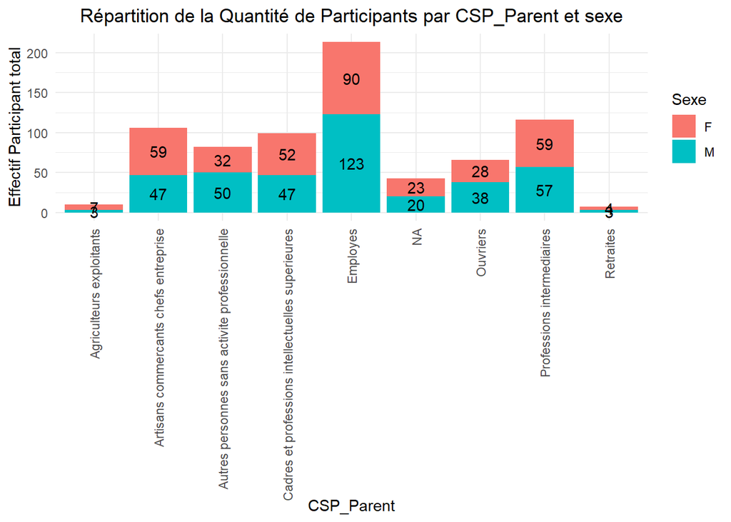

```r
# Créer le diagramme en barres empilées avec les modalités en abscisses affichées verticalement
ggplot(CSP_data, aes(x = CSP_Parent, y = Effectif_Participant_total, fill = sexe)) +
  geom_bar(stat = "identity") +
  geom_text(aes(label = Effectif_Participant_total), position = position_stack(vjust = 0.5), color = "black") +
  labs(x = "CSP_Parent", y = "Effectif Participant total", fill = "Sexe", title = "Répartition de la Quantité de Participants par CSP_Parent et sexe") +
  theme_minimal() +
  theme(
    plot.title = element_text(hjust = 0.5),
    axis.text.x = element_text(angle = 90, vjust = 0.5, hjust = 1)
  )  # Modifier l'angle des modalités sur l'axe x
```

Voici le tableau des effectifs des participants dont l’un de ses parents au moins exerce une des fonctions ci dessous :

|  | Filles | Garçons | Population Globale |
| --- | --- | --- | --- |
| Agriculteurs exploitants | 7 | 3 | 10 |
| Artisans commercants chefs entreprise | 59 | 47 | 106 |
| Autres personnes sans activite professionnelle | 32 | 50 | 82 |
| Cadres et professions intellectuelles superieures | 52 | 47 | 99 |
| Employes | 90 | 123 | 213 |
| Ouvriers | 28 | 38 | 66 |
| Professions intermediaires | 59 | 57 | 116 |
| Retraites | 4 | 3 | 7 |
| NA | 23 | 20 | 43 |

### Statistique descriptive pour le lieu d’étude :

- Proportion de l’échantillon global de la population selon le genre

```r
prop.table(table(data$gender))*100
```

```
##
##        F        M
## 47.70889 52.29111
```

- **Proportion de l’échantillon global de la population selon le CA**

```r
prop.table(table(data$CA,data$gender))*100
```

```
##
##             F         M
##   1  5.121294  7.008086
##   2 13.746631 12.398922
##   3  4.312668  5.929919
##   4 24.528302 26.954178
```

| **CA** | **1** | **2** | **3** | **4** |
| --- | --- | --- | --- | --- |
| **Proportion(%)** | 12.13 | 26.15 | 10.24 | 51.48 |

Illustration avec un barplot :

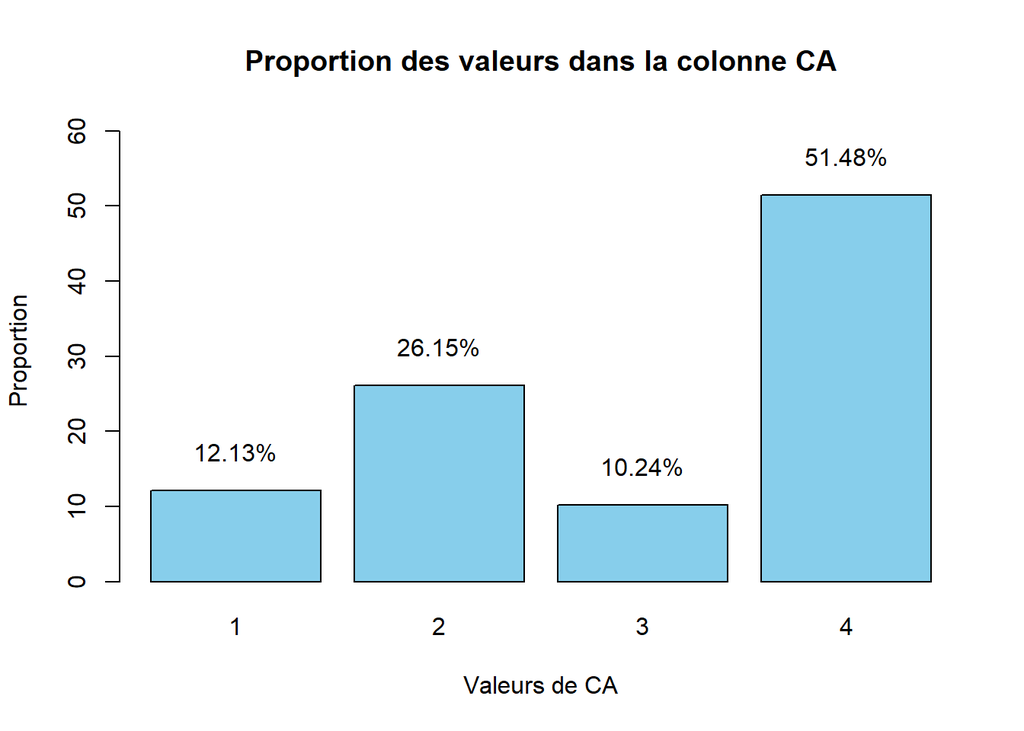

```r
# Calculer les proportions
proportions <- prop.table(table(data$CA)) * 100

# Créer le barplot
barplot(proportions, main = "Proportion des valeurs dans la colonne CA",
        xlab = "Valeurs de CA", ylab = "Proportion", col = "skyblue",
        ylim=c(0, max(proportions) + 10))  # Ajuster ylim pour éviter le chevauchement du texte

# Ajouter les proportions sur les barres
text(x = barplot(proportions, plot = FALSE),  # Obtenir les positions en x des barres
     y = proportions+2,  # Décaler légèrement le texte au-dessus des barres
     labels = sprintf("%.2f%%", proportions),  # Formater les proportions avec deux décimales
     pos = 3)  # Positionner le texte au-dessus des barres (3 = au-dessus)
```

- **Proportion de l’échantillon global de la population selon l’IPS**

**-IPS faible inférieur à 89**

**-IPS moyenne entre 90 et 114**

**-IPS élevé supérieur à 115**

```r
prop.table(table(data$IPS_categorie,data$gender))*100
```

```
##
##                  F        M
##   Élevée  16.17251 14.82480
##   Faible  11.85984 10.51213
##   Moyenne 19.67655 26.95418
```

[output not shown]

Illustration avec un barplot

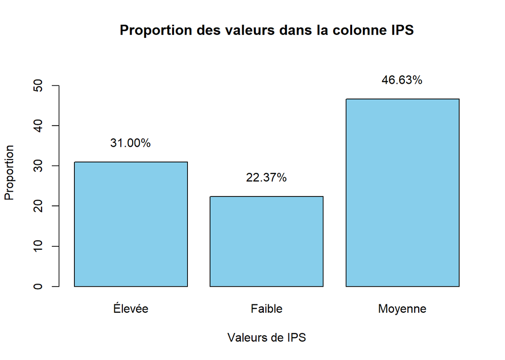

```r
# Calculer les proportions pour la colonne IPS_categorie
proportions_ips = prop.table(table(data$IPS_categorie)) * 100

# Créer le barplot pour IPS_categorie
bp <- barplot(proportions_ips, main = "Proportion des valeurs dans la colonne IPS",
              xlab = "Valeurs de IPS", ylab = "Proportion", col = "skyblue",
              ylim = c(0, max(proportions_ips) + 10))  # Ajuster ylim pour éviter le chevauchement du texte

# Ajouter les proportions sur les barres
text(x = bp,  # Positions en x des barres, retournées par barplot
     y = proportions_ips + 2,  # Ajouter un petit espace au-dessus de chaque barre pour le texte
     labels = sprintf("%.2f%%", proportions_ips),  # Formater les proportions avec deux décimales
     pos = 3)  # Poser le texte au-dessus des barres
```

- **Proportion de l’échantillon global de la population selon le milieu géographique**

```r
prop.table(table(data$Geographie,data$gender))*100
```

```
##
##                 F        M
##   rural  17.78976 18.05930
##   urbain 29.91914 34.23181
```

| **Milieu géographique** | **urbain** | **rural** |
| --- | --- | --- |
| **Proportion(%)** | 64.15 | 35.85 |

Illustration avec un barplot

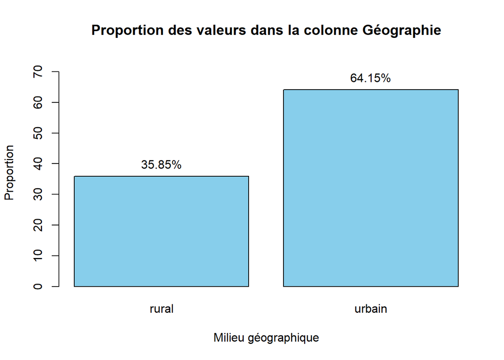

```r
# Calculer les proportions pour la colonne Géographie
proportions_geo = prop.table(table(data$Geographie)) * 100

# Créer le barplot pour Géographie
bp_geo <- barplot(proportions_geo, main = "Proportion des valeurs dans la colonne Géographie",
                  xlab = "Milieu géographique", ylab = "Proportion", col = "skyblue",
                  ylim = c(0, max(proportions_geo) + 10))  # Ajuster ylim pour éviter le chevauchement du texte

# Ajouter les proportions sur les barres
text(x = bp_geo,  # Positions en x des barres, retournées par barplot
     y = proportions_geo + 0.25,  # Ajouter un petit espace au-dessus de chaque barre pour le texte
     labels = sprintf("%.2f%%", proportions_geo),  # Formater les proportions avec deux décimales
     pos = 3)  # Poser le texte au-dessus des barres
```